# Puget Sound Rockfish

*Sebastes emphaeus*

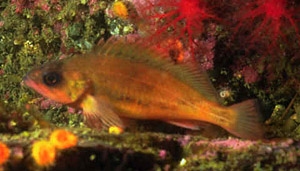

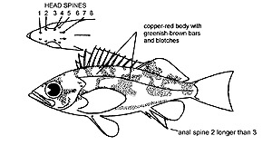

**Body color:** Copper-red w/ indefinite olivaceous blotches; green bands radiate from eye; spinous dorsal green, w/ bright red at tips of spines; outer soft dorsal bright red, base of fin dark; paired and anal fins clear, brillant red. (Also see above photo.)

**Peritoneum color:** dark **Shape between eyes:** convex

**Counts:** D:XIII,13-15, Ar:6-7, P1:16-18, GR:37-41, LLp:40-46, LLs:41-46, V:27-28

**Occurence:** Gulf of Alaska - Northern California

**Depth:** 366 meters **Size:** 18 cm **Species code:** 30210

**Similar species:**

- *Pygmy rockfish* - brownish-red stripe below lateral line, squared blotches at base of dorsal fin; anal rays typically 6 (typically 7 in Puget Sound RF)
- *Shortbelly rockfish* - anus about midway between origin of anal fin and pelvic-fin base (immediately in front of anal fin in Puget Sound RF); anal spine 2 shorter than 3
- *Sharpchin rockfish* - dorsal blotches extend below lateral line; symphyseal knob sharp and prominent; strong dark stripes extend posterior to eye
- *Pacific Ocean Perch* - symphyseal knob sharp, elongate; head spines weak and count typically differs; anal spine 2 shorter than 3

Back to Group

**Corrections:** If you see mistakes or want to suggest changes, please create an [issue](https://github.com/zoyafuso-NOAA/RACE_Survey_App/issues) on the source repository or

*reach out to Liz Dawson (Liz.Dawson AT noaa.gov).*